# Sphyrnidae

BOLDGenotyper Analysis Report

Generated: 2025-11-19 19:16:40

BOLDGenotyper v1.0.0

995

Total Samples

11

Genotypes

97.1%

Assignment Rate

Executive Summary Genotype Assignment Taxonomy Geographic Distribution Visualizations

## Analysis Summary

Total Samples

995

Samples analyzed

With Sequence Data

969

97.4% of total

Consensus Groups

11

Unique genotypes identified

Species Identified

7

Distinct species

Successfully Assigned

966

97.1% assignment rate

Mean Identity

For assigned samples

Geographic coverage

## Pipeline Parameters

The following parameters were used for this analysis:

| Parameter | Value | Description |
| --- | --- | --- |
| **Clustering Threshold** | `0.03` (97.0% identity) | Maximum genetic distance for grouping sequences into consensus genotypes. Lower values create more groups with tighter genetic similarity. |
| **Similarity Threshold** | `0.5` (50% identity) | Minimum sequence identity required for assigning samples to genotypes. Samples below this threshold are marked as unassigned. |
| **Tie Margin** | `0.003` (0.3% difference) | Maximum identity difference between top matches to flag as ambiguous. Samples with (best - runner-up) < tie margin are flagged for manual review. |
| **Tie Threshold** | `0.95` (95% identity) | Minimum best-match identity required to consider tie detection. Prevents flagging low-quality matches as ties. |
| **Threads** | `4` | Number of parallel processing threads used. |
| **Phylogenetic Tree** | `True` | Whether phylogenetic tree was constructed. |

## Genotype Assignment Results

### Assignment Status Breakdown

| Status | Count | Percentage |
| --- | --- | --- |
| Successfully Assigned | 966 | 97.1% |
| Low Confidence | 0 | 0.0% |
| Tied Assignment | 0 | 0.0% |
| Below Threshold | 3 | 0.3% |
| No Sequence Data | 26 | 2.6% |

### Identity Score Statistics (Assigned Samples)

[output not shown]

## Taxonomy

### Consensus Group Taxonomy

| consensus_group | assigned_sp | assignment_level | assignment_notes | majority_fraction |
| --- | --- | --- | --- | --- |
| consensus_c10_n259 | Sphyrna | genus | tie or not majority; fell back to genus | 0.409266 |
| consensus_c11_n2 | Sphyrna lewini | species | majority 1.00 | 1.000000 |
| consensus_c12_n1 | Sphyrna zygaena | species | majority 1.00 | 1.000000 |
| consensus_c1_n2 | Sphyrna tiburo | species | majority 1.00 | 1.000000 |
| consensus_c2_n19 | Sphyrna tiburo | species | majority 0.84 | 0.842105 |
| consensus_c3_n67 | Sphyrna | genus | tie or not majority; fell back to genus | 0.656716 |
| consensus_c4_n3 | Eusphyra blochii | species | majority 1.00 | 1.000000 |
| consensus_c5_n1 | Sphyrna mokarran | species | majority 1.00 | 1.000000 |
| consensus_c6_n4 | Sphyrna zygaena | species | majority 1.00 | 1.000000 |
| consensus_c7_n5 | Sphyrna corona | species | majority 1.00 | 1.000000 |
| consensus_c9_n603 | Sphyrna lewini | species | majority 0.81 | 0.805970 |

### Species Composition by Consensus Group

| consensus_group | reported_species | n | frac | n_in_group |
| --- | --- | --- | --- | --- |
| consensus_c10_n259 | Eusphyra blochii | 6 | 0.023166 | 259.0 |
| consensus_c10_n259 | Sphyrna lewini | 106 | 0.409266 | 259.0 |
| consensus_c10_n259 | Sphyrna mokarran | 65 | 0.250965 | 259.0 |
| consensus_c10_n259 | Sphyrna zygaena | 82 | 0.316602 | 259.0 |
| consensus_c11_n2 | Sphyrna lewini | 2 | 1.000000 | 2.0 |
| consensus_c12_n1 | Sphyrna zygaena | 1 | 1.000000 | 1.0 |
| consensus_c1_n2 | Sphyrna tiburo | 2 | 1.000000 | 2.0 |
| consensus_c2_n19 | Sphyrna tiburo | 16 | 0.842105 | 19.0 |
| consensus_c2_n19 | Sphyrna tudes | 2 | 0.105263 | 19.0 |
| consensus_c2_n19 | Sphyrna zygaena | 1 | 0.052632 | 19.0 |
| consensus_c3_n67 | Sphyrna lewini | 1 | 0.014925 | 67.0 |
| consensus_c3_n67 | Sphyrna tiburo | 44 | 0.656716 | 67.0 |
| consensus_c3_n67 | Sphyrna tudes | 22 | 0.328358 | 67.0 |
| consensus_c4_n3 | Eusphyra blochii | 3 | 1.000000 | 3.0 |
| consensus_c5_n1 | Sphyrna mokarran | 1 | 1.000000 | 1.0 |
| consensus_c6_n4 | Sphyrna zygaena | 4 | 1.000000 | 4.0 |
| consensus_c7_n5 | Sphyrna corona | 5 | 1.000000 | 5.0 |
| consensus_c9_n603 | Eusphyra blochii | 5 | 0.008292 | 603.0 |
| consensus_c9_n603 | Sphyrna lewini | 486 | 0.805970 | 603.0 |
| consensus_c9_n603 | Sphyrna mokarran | 40 | 0.066335 | 603.0 |
| consensus_c9_n603 | Sphyrna tiburo | 20 | 0.033167 | 603.0 |
| consensus_c9_n603 | Sphyrna tudes | 3 | 0.004975 | 603.0 |
| consensus_c9_n603 | Sphyrna zygaena | 49 | 0.081260 | 603.0 |
| NaN | Sphyrna lewini | 22 | NaN | NaN |
| NaN | Sphyrna mokarran | 1 | NaN | NaN |
| NaN | Sphyrna tudes | 1 | NaN | NaN |
| NaN | Sphyrna zygaena | 5 | NaN | NaN |

## Geographic Distribution

**Geographic Analysis Summary:** 113 of 995 samples (11.4%) have defined geographic locations. 882 samples (88.6%) with unknown or missing geography were excluded from geographic analyses.

### Sample Distribution by Ocean Basin

| Ocean Basin | Sample Count | Percentage |
| --- | --- | --- |
| South China and Easter Archipelagic Seas | 42 | 37.2 |
| Indian Ocean | 32 | 28.3 |
| North Atlantic Ocean | 21 | 18.6 |
| South Pacific Ocean | 12 | 10.6 |
| South Atlantic Ocean | 5 | 4.4 |
| North Pacific Ocean | 1 | 0.9 |

### Genotypes per Ocean Basin

| ocean_basin | consensus_group | Indian Ocean | North Atlantic Ocean | North Pacific Ocean | South Atlantic Ocean | South China and Easter Archipelagic Seas | South Pacific Ocean |
| --- | --- | --- | --- | --- | --- | --- | --- |
|  | consensus_c10_n259 | 12 | 10 | 1 | 1 | 11 | 8 |
|  | consensus_c2_n19 | 0 | 2 | 0 | 0 | 0 | 0 |
|  | consensus_c3_n67 | 0 | 5 | 0 | 0 | 0 | 0 |
|  | consensus_c9_n603 | 20 | 4 | 0 | 4 | 31 | 4 |

## Visualizations

### Phylogenetic Tree

Phylogenetic tree showing relationships between consensus groups

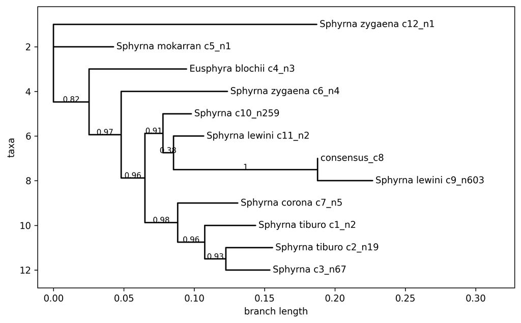

### Identity Distribution

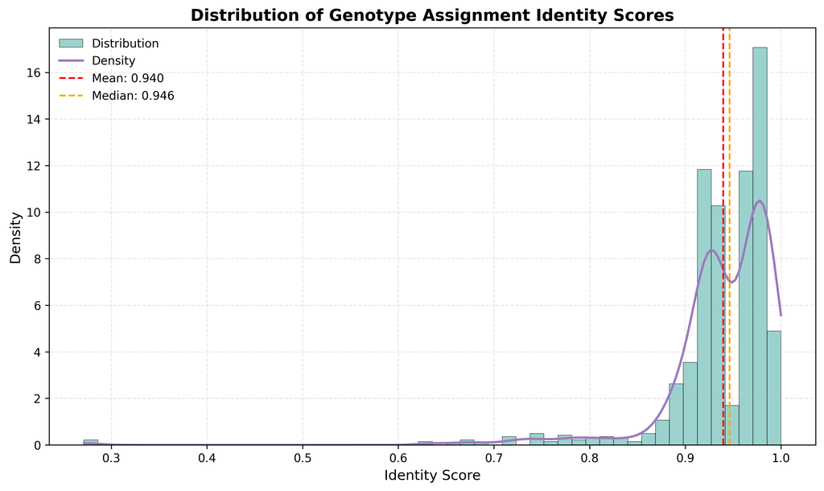

### Distribution Map

Geographic distribution of samples

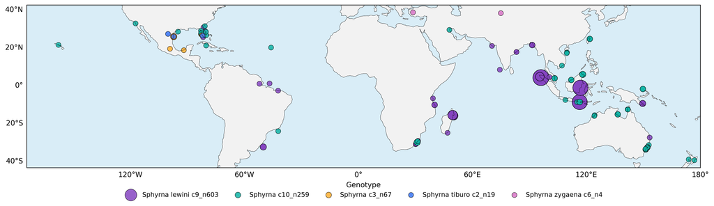

### Distribution Map (Faceted)

Geographic distribution faceted by species or genotype

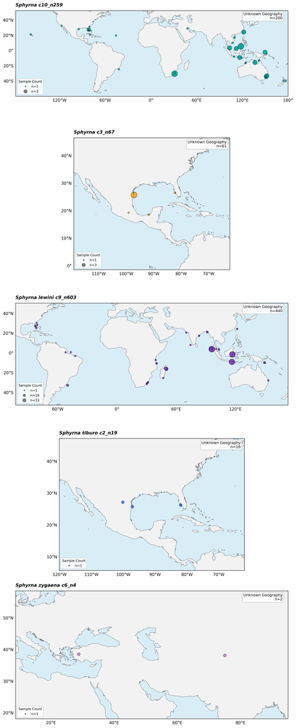

### Relative Abundance by Ocean Basin

Relative abundance of genotypes across ocean basins

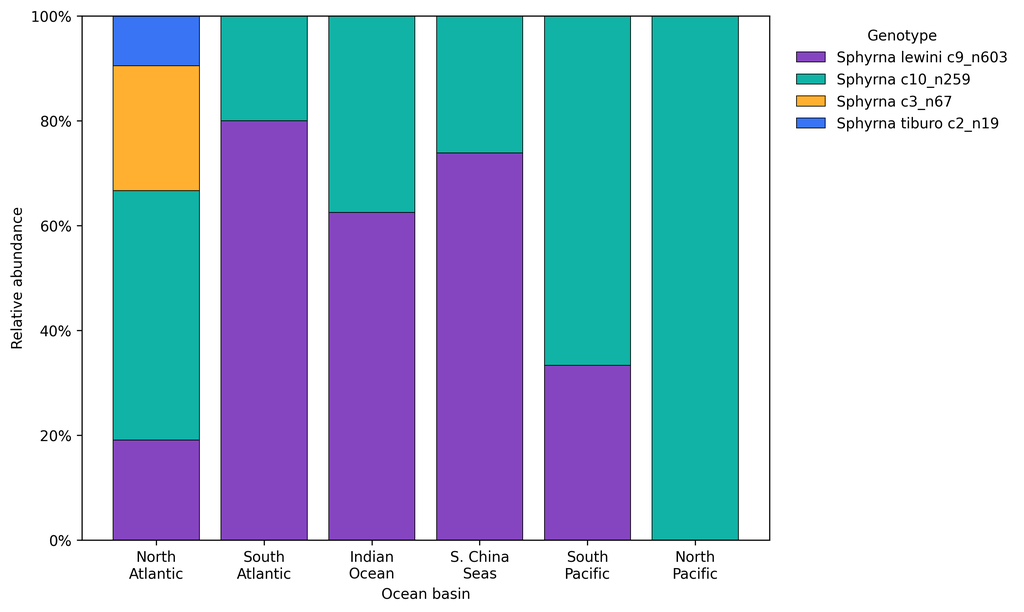

### Relative Abundance by Ocean Basin (Faceted)

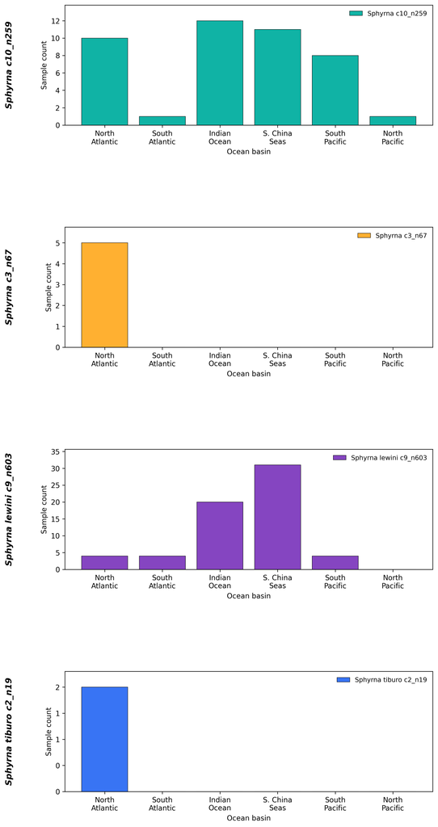

### Total Abundance by Ocean Basin

Total sample counts of genotypes across ocean basins

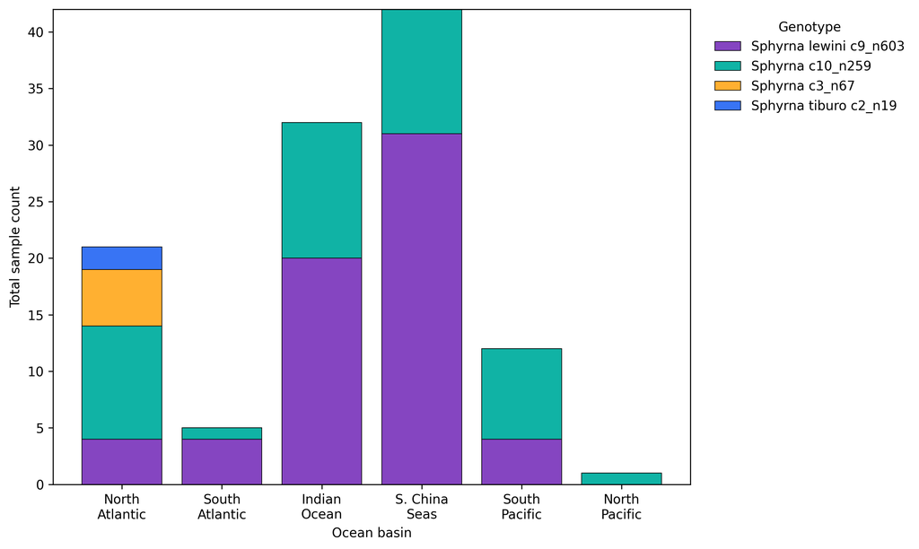

**BOLDGenotyper** - Automated genotyping pipeline for BOLD barcode data  
[GitHub Repository](https://github.com/anthropics/boldgenotyper)

Report generated on 2025-11-19 19:16:40  
For questions or issues, please visit the GitHub repository.